# IMF Online Course: Macroeconomic forecasting

## Module 3B: Statistical Properties of Time Series Data

### Testing for Nonstationarity and Unit Roots

**Author**: Miha Trošt  
**Date**: 29-01-2016

```r
# useful libraries
library(plyr)
library(dplyr)
library(forecast)
library(stringr)
library(lubridate)
library(tidyr)
library(broom)
```

```r
my_wd <-
  "C:/Users/Miha/Documents/GitHub/IMF_Macro_Forecasting_R/003_module_3b_Statistical_properties_of_time_series/M3B_Assessments Workfile/"

my_non_st_df <-
  read.csv(str_c(my_wd, "module3b_data_Simulated_Nonstationary.CSV"),
           sep = ",",
           stringsAsFactors = FALSE)
```

### Identifying Non-Stationarity

Given two series m<sub>t</sub> and n<sub>t</sub> defined by the following equations:

1. **m<sub>t</sub> = 1.5 + m<sub>t-1</sub> + e<sub>mt</sub>**
2. **n<sub>t</sub> = -2 + n<sub>t-1</sub> + e<sub>nt</sub>**

where **e<sub>mt</sub>** and **e<sub>nt</sub>** are both white noise. In the `module3b_data_Simulated_Nonstationary.csv` file you are given the series `em` and `en` representing **e<sub>mt</sub>** and **e<sub>nt</sub>** respectively. Study the graphs of the series **m<sub>t</sub>** and **n<sub>t</sub>**.

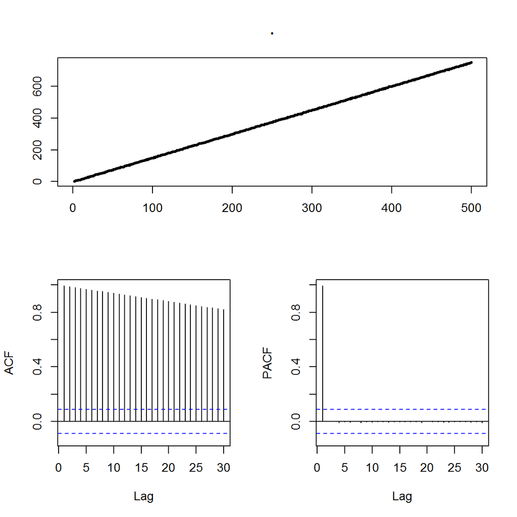

```r
# optional m
m_t <- vector()
m_t <- 0

n_rep <- 500
em <- my_non_st_df$em

for(i in 2:n_rep){

  m_t[i] <- 1.5 + m_t[i - 1] + em[i]

}


# optional n
n_t <- vector()
n_t <- 0

n_rep <- 500
en <- my_non_st_df$en

for(i in 2:n_rep){

  n_t[i] <- -2 + n_t[i - 1] + en[i]

}

# dplyr way of doing things
my_seria <-
  my_non_st_df %>%
  mutate(m_t = 1.5 + lag(m, 1) + em,
         n_t = -2 + lag(n, 1) + en) %>%
  select(m_t, n_t)

my_seria$m_t %>% tsdisplay(., lag.max = 30)
```

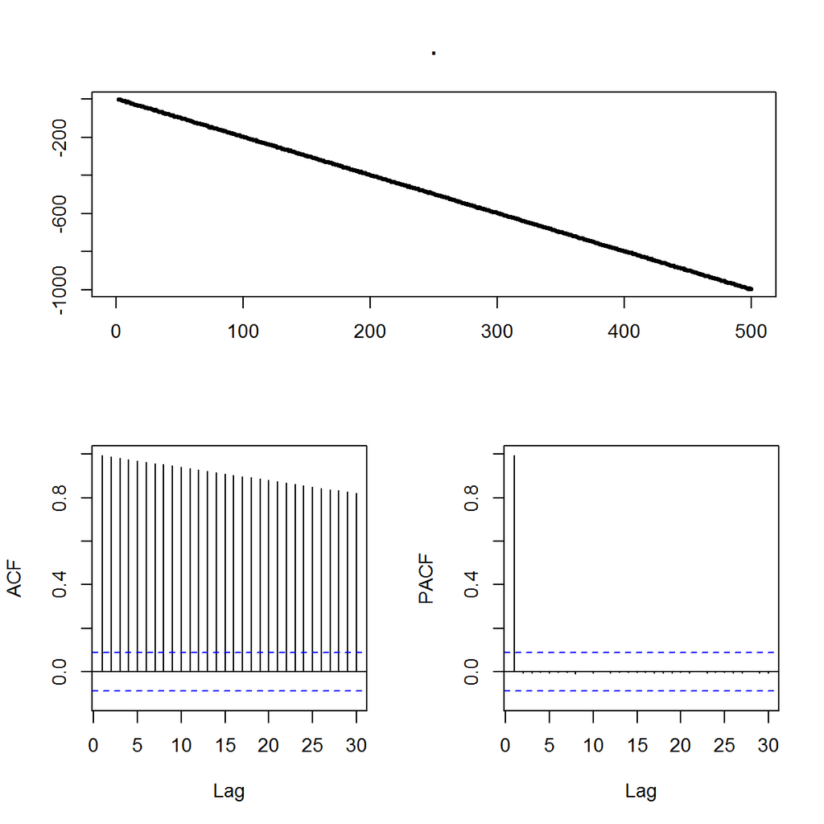

```r
my_seria$n_t %>% tsdisplay(., lag.max = 30)
```

Optional: You are encouraged to generate m<sub>t</sub> and n<sub>t</sub> where the initial values of m<sub>t</sub> and n<sub>t</sub> are zero (see Module 3A Question 3.9 for an example of how to generate the series).

#### QUESTION 3.36

These two series, `m` and `n`, are stationary:

Answer is **FALSE**, since they have a positive (`m`) and negative (`n`) trend

### Nonstationary Data

#### QUESTION 3.37

Observing the correlogram for each series, at which lag does the ACF become statistically insignificant? Use a 5 percent level of significance to decide.

Answer: They do not die out.

#### QUESTION 3.38

Estimate an AR(1) model for `m` and for `n`. Enter the corresponding estimated autoregressive coefficient (to four decimal places, without any rounding):

```r
model_m <-
  Arima(my_seria$m_t, c(1, 0, 0))

model_n <-
  Arima(my_seria$n_t, c(1, 0, 0))

summary(model_m)
```

```
Series: my_seria$m_t
ARIMA(1,0,0) with non-zero mean

Coefficients:
      ar1  intercept
        1  34135.299
s.e.    0   2180.953

sigma^2 estimated as 1.902:  log likelihood=-868.96
AIC=1743.92   AICc=1743.96   BIC=1756.56

Training set error measures:
                     ME     RMSE      MAE       MPE     MAPE     MASE         ACF1
Training set -0.6447695 14.47001 1.744912 -37.69174 38.49394 1.034592 -0.009208978
```

```r
summary(model_n)
```

```
Series: my_seria$n_t
ARIMA(1,0,0) with non-zero mean

Coefficients:
      ar1  intercept
        1  -514.6043
s.e.    0    53.9362

sigma^2 estimated as 6.057:  log likelihood=-1157.95
AIC=2321.9   AICc=2321.95   BIC=2334.55

Training set error measures:
                    ME     RMSE      MAE       MPE     MAPE     MASE       ACF1
Training set -1.981553 2.467241 2.127282 0.8247905 1.389109 1.001597 -0.4351007
```

They are practically 1.

#### QUESTION 3.39

Run a regression of `m` on `n`, together with a constant term. Which of the following statements accurately represents the regression results? (Choose all that apply)

```r
my_lm <- lm(my_seria$n_t ~ my_seria$m_t)

summary(my_lm)
```

```
Call:
lm(formula = my_seria$n_t ~ my_seria$m_t)

Residuals:
    Min      1Q  Median      3Q     Max
-5.3758 -1.2270  0.0606  1.2031  5.4492

Coefficients:
               Estimate Std. Error   t value Pr(>|t|)
(Intercept)   0.0164076  0.1511201     0.109    0.914
my_seria$m_t -1.3336486  0.0003493 -3818.387   <2e-16 ***
---
Signif. codes:  0 '***' 0.001 '**' 0.01 '*' 0.05 '.' 0.1 ' ' 1

Residual standard error: 1.685 on 497 degrees of freedom
  (1 observation deleted due to missingness)
Multiple R-squared:      1, Adjusted R-squared:      1
F-statistic: 1.458e+07 on 1 and 497 DF,  p-value: < 2.2e-16
```

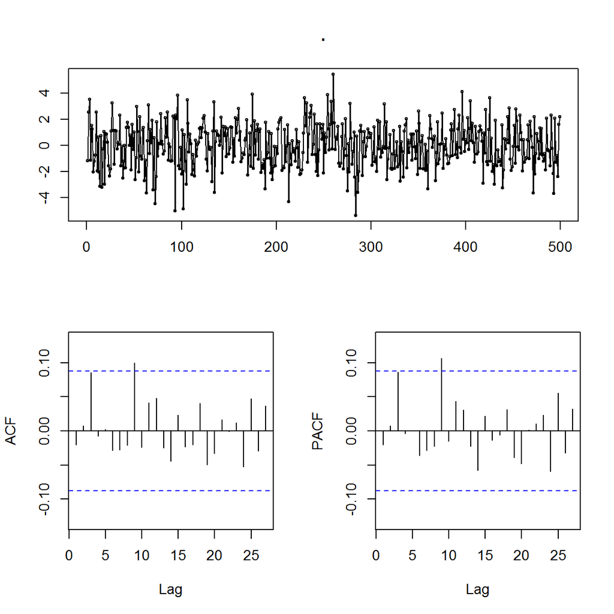

```r
resid(my_lm) %>% tsdisplay()
```

My residuals appear to be white noise, so I could not get the right answer. Below is an explanation from the IMF staff.

**Explanation**: *The regression has very good fit (R2 of over 0.99), and the coefficient of n has a very large t-statistic, therefore suggesting a highly significant relationship between the two variables. However, note that the regression residuals appear to be nonstationary, with an ACF that decays very slowly. The Q-test of zero autocorrelation is overwhelmingly rejected at all lags up to 36. The strong association should therefore be described as spurious, since these two series by construction are actually unrelated (i.e., there is no relationship between them).*

**However, from the discussion forum, one student correctly observed that**: *This question is not well written and does not reflect the lecture’s message. The seemingly good fit and the high t-statistics are spurious. One cannot evaluate the residuals due to perfect separation. Thus, one cannot even assess the model fit and model coefficient. Whether there is a long-run relationship or not cannot be assessed either. If you cannot save residuals and see whether they are white noise or not, how can you decide m an n are cointegrated? Very badly written and misleading question.*

```r
# linear regression with simulated values
my_lm_optional_sim_values <- lm(n_t ~ m_t)

summary(my_lm_optional_sim_values)
```

```
Call:
lm(formula = n_t ~ m_t)

Residuals:
    Min      1Q  Median      3Q     Max
-21.390  -6.317  -2.059   6.158  25.232

Coefficients:
            Estimate Std. Error  t value Pr(>|t|)
(Intercept)   4.6546     0.7863    5.919 6.02e-09 ***
m_t          -1.3871     0.0019 -730.065  < 2e-16 ***
---
Signif. codes:  0 '***' 0.001 '**' 0.01 '*' 0.05 '.' 0.1 ' ' 1

Residual standard error: 8.659 on 498 degrees of freedom
Multiple R-squared:  0.9991,    Adjusted R-squared:  0.9991
F-statistic: 5.33e+05 on 1 and 498 DF,  p-value: < 2.2e-16
```

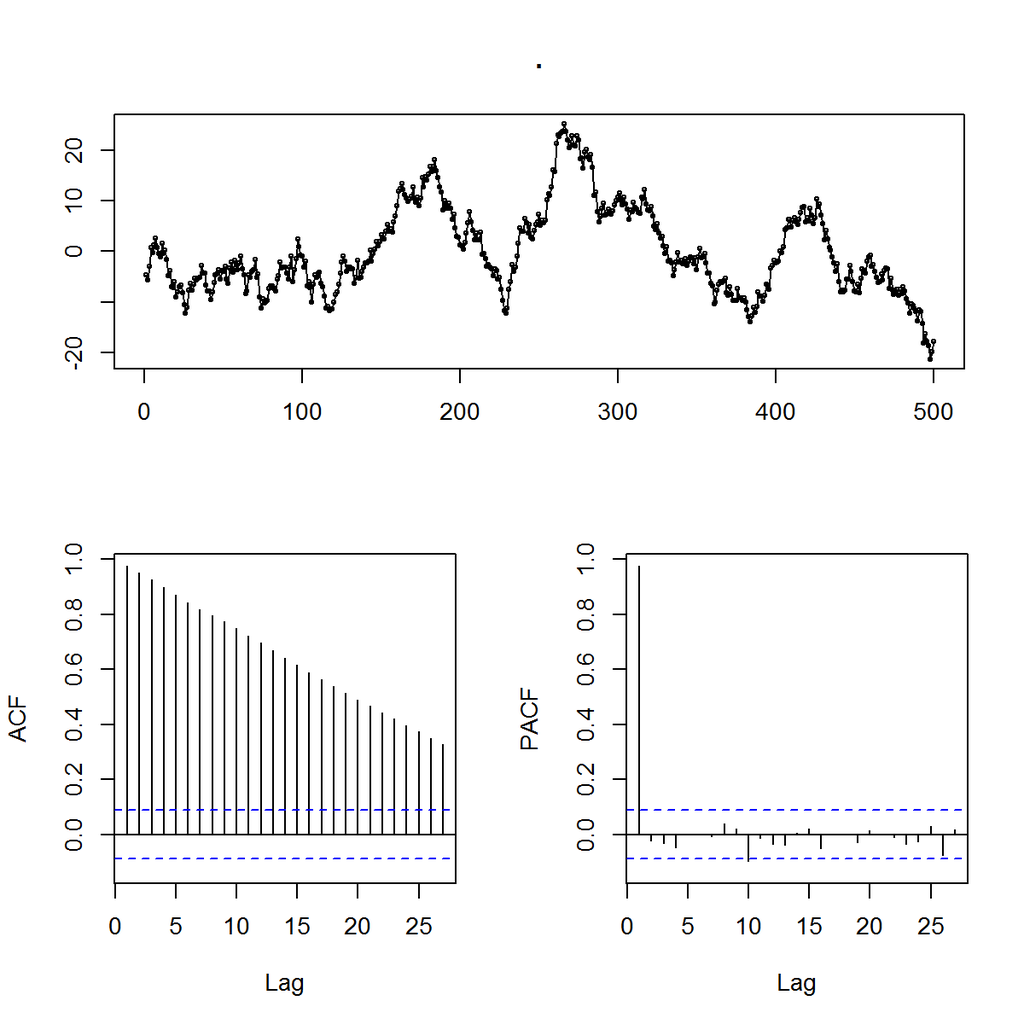

```r
resid(my_lm_optional_sim_values) %>% tsdisplay()
```

If I were to simulate `m` and `n` in the first place, I would have answered correctly. Residuals do not die out.